# Домашняя работа №5.

# Саенко Анастасия

Загрузим необходимые библиотеки

```r
library(haven)
library(ggplot2)
library(sandwich)
library(lmtest)
library(car)
library(dplyr)
library(broom)
library(olsrr)
library(memisc)
```

## Загрузим данные

```r
data <- read_dta( "https://politologi-tvims2.github.io/hw15.dta" )
data <- na.omit(data)
```

## Построим простую линейную модель

```r
ml <- lm(data$ch_schools_pc~data$afreq+data$nozemstvo+data$distance_moscow+data$goodsoil+data$lnurban+data$lnpopn+data$province_capital, data = data)
summary(ml)
```

```
##
## Call:
## lm(formula = data$ch_schools_pc ~ data$afreq + data$nozemstvo +
##     data$distance_moscow + data$goodsoil + data$lnurban + data$lnpopn +
##     data$province_capital, data = data)
##
## Residuals:
##      Min       1Q   Median       3Q      Max
## -0.33950 -0.09568 -0.03539  0.04702  1.45789
##
## Coefficients:
##                        Estimate Std. Error t value Pr(>|t|)
## (Intercept)            0.676390   0.218253   3.099 0.002055 **
## data$afreq            -0.179940   0.054391  -3.308 0.001009 **
## data$nozemstvo         0.081681   0.021824   3.743 0.000204 ***
## data$distance_moscow  -0.012284   0.031880  -0.385 0.700184
## data$goodsoil         -0.009406   0.024005  -0.392 0.695347
## data$lnurban           0.013754   0.007281   1.889 0.059494 .
## data$lnpopn           -0.042032   0.019883  -2.114 0.035030 *
## data$province_capital  0.038771   0.030189   1.284 0.199664
## ---
## Signif. codes:  0 '***' 0.001 '**' 0.01 '*' 0.05 '.' 0.1 ' ' 1
##
## Residual standard error: 0.1782 on 480 degrees of freedom
## Multiple R-squared:  0.1032, Adjusted R-squared:  0.09014
## F-statistic: 7.892 on 7 and 480 DF,  p-value: 4.526e-09
```

## Визуализации отношения между предикторами и зависимой переменной

```r
data <-  dplyr::select(data,c(afreq,nozemstvo,distance_moscow,goodsoil,lnurban,lnpopn,province_capital,ch_schools_pc))
```

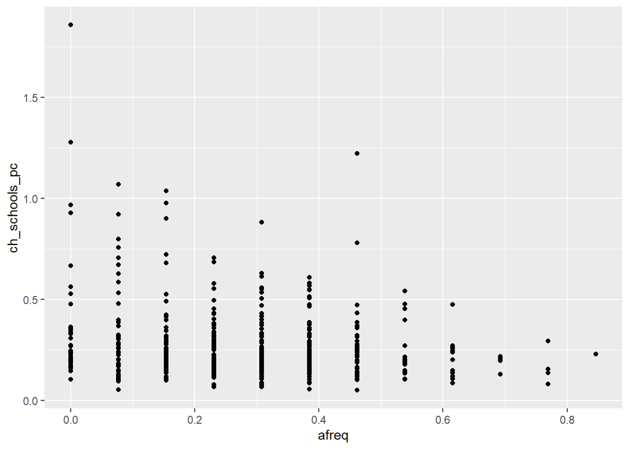

```r
ggplot(data = data, aes(afreq,ch_schools_pc )) + geom_point()
```

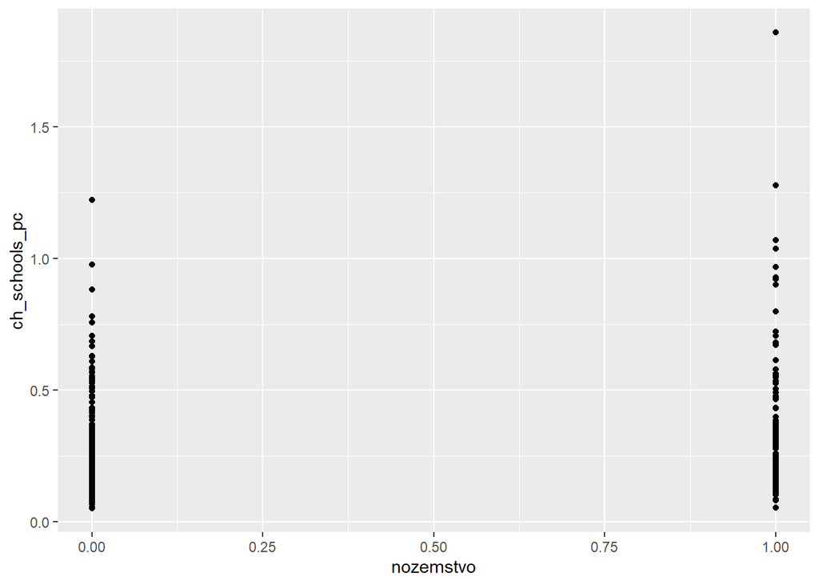

```r
ggplot(data = data, aes(nozemstvo,ch_schools_pc )) + geom_point()
```

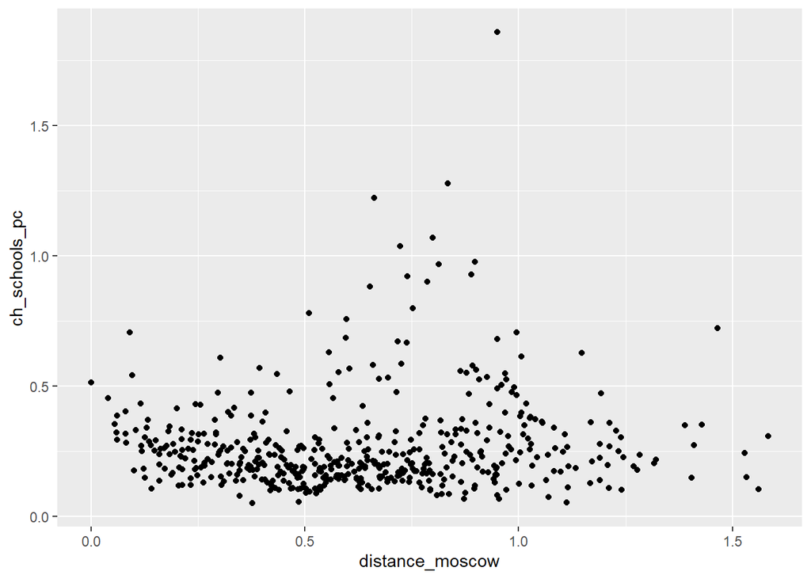

```r
ggplot(data = data, aes(distance_moscow,ch_schools_pc )) + geom_point()
```

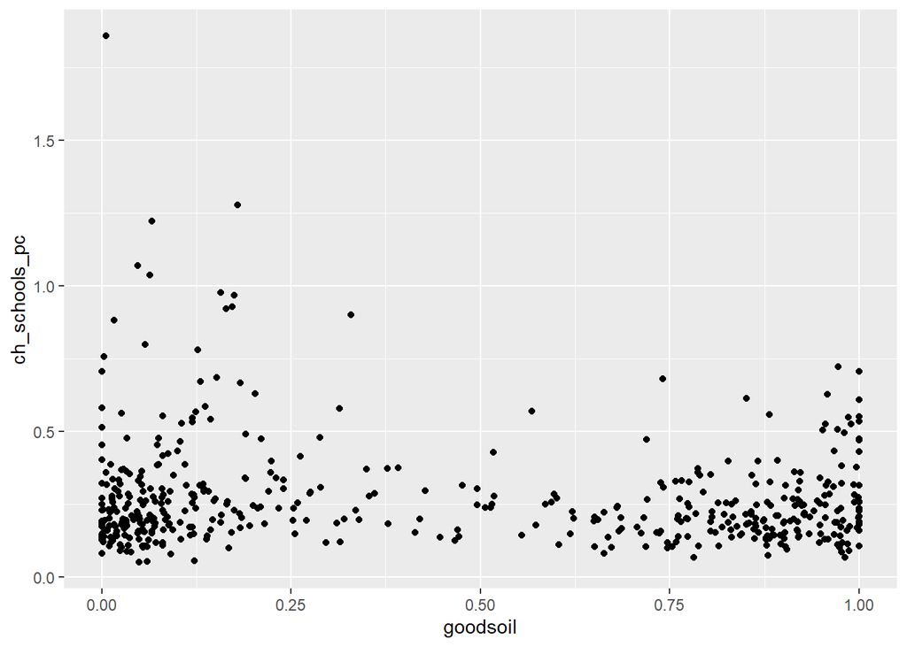

```r
ggplot(data = data, aes(goodsoil,ch_schools_pc )) + geom_point()
```

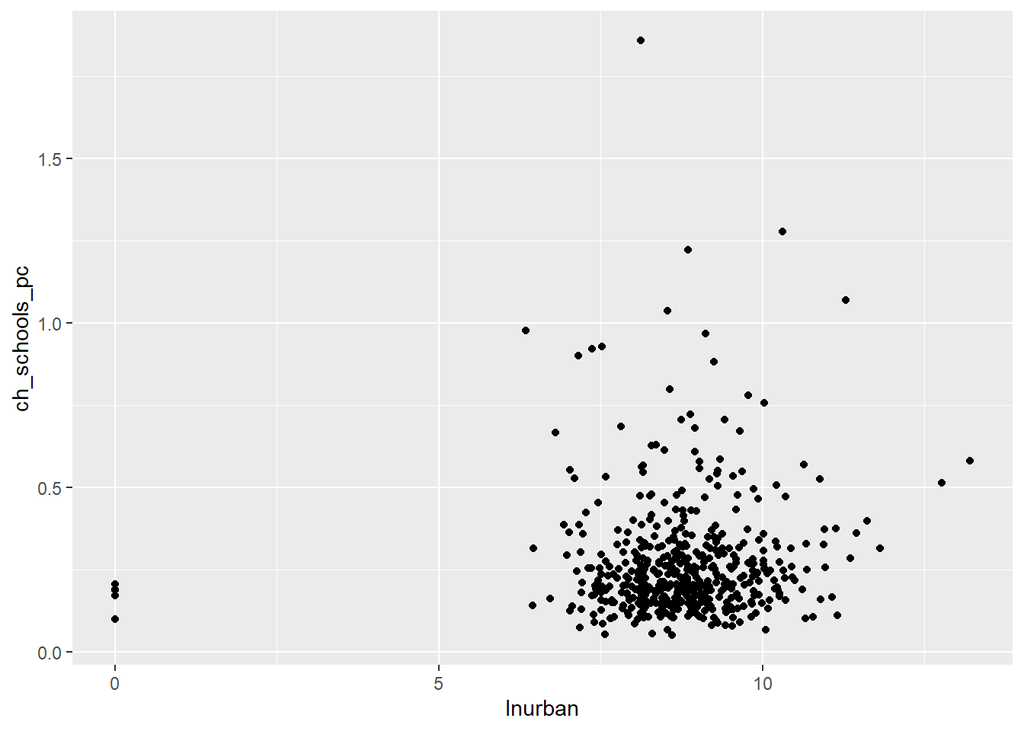

```r
ggplot(data = data, aes(lnurban,ch_schools_pc )) + geom_point()
```

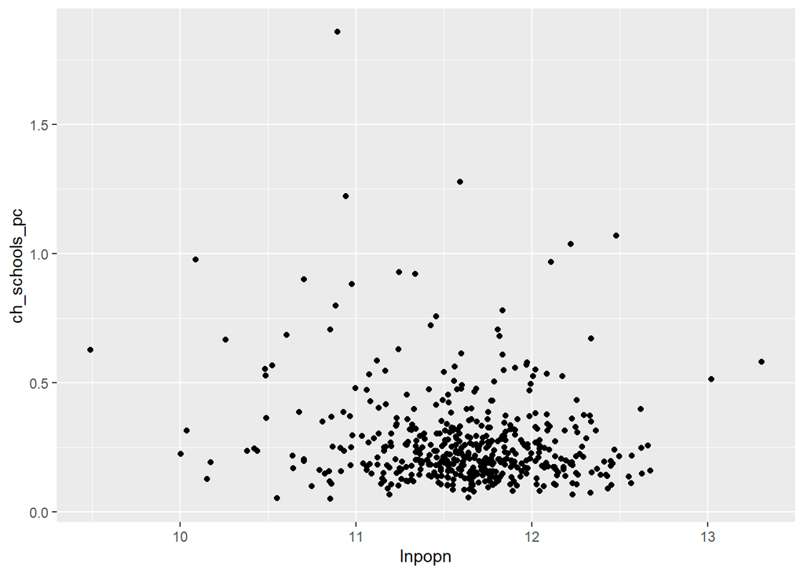

```r
ggplot(data = data, aes(lnpopn,ch_schools_pc )) + geom_point()
```

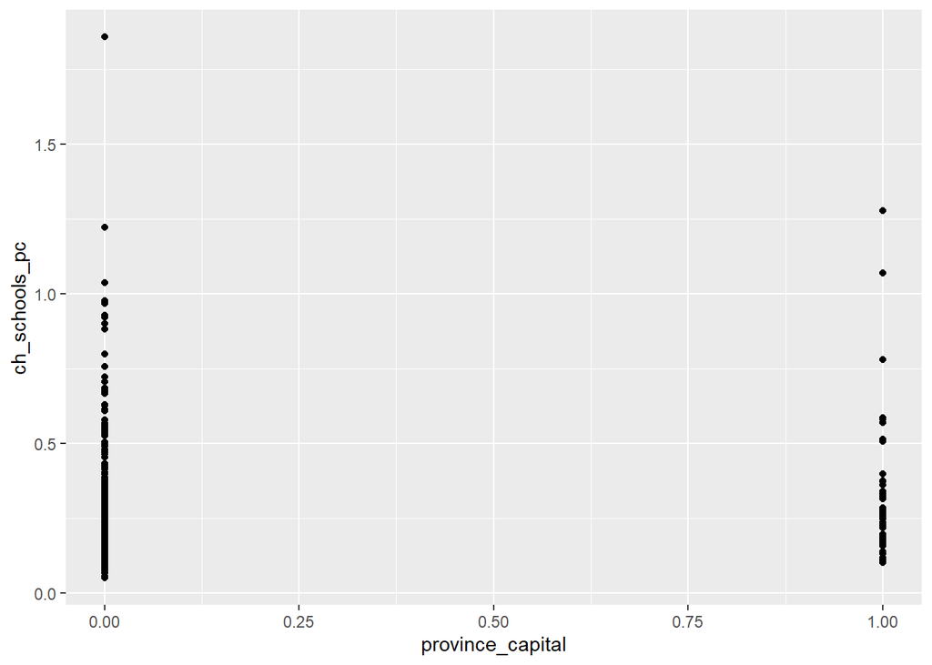

```r
ggplot(data = data, aes(province_capital,ch_schools_pc )) + geom_point()
```

На данных графиков видно, что разброс точек относительно условного их скопления ( или условной прямой, которую можно провести ) не везде постоянный. Особенно это видно на графике с distance moscow( там имеют место быть и выбросы, которые могут вредить модели), lnurban, lnpopn. По данным графикам мы можем видет отклонения точек, где соотвественно расстояния являются остатками. Для дальнейшей визуализации лучше посмотреть напрямую на остатки.

## Визуалиция отношения между fitted values и зависимой переменной

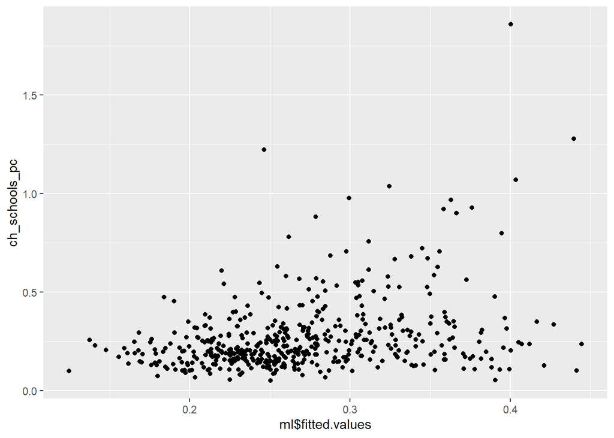

```r
ggplot(data = data, aes(ml$fitted.values,ch_schools_pc )) + geom_point()
```

На этом графике также виден разброс фактической зависимой переменной относительно ее модельных значений. Видно, что с ростом по оси x идет рост разброса фактических значений, то есть есть основания полагать о высокой вариации остатков относительно модельных значений. Перейдем к анализу остатков.

## Rss и предикторами

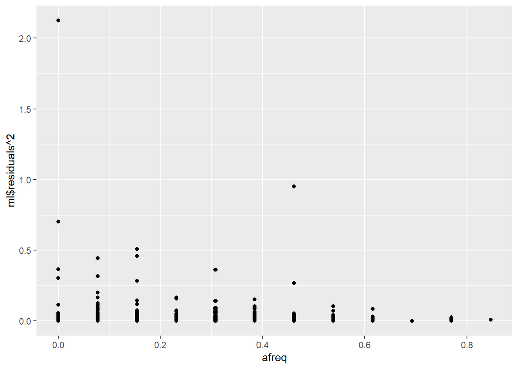

```r
ggplot(data = data, aes(afreq,ml$residuals^2 )) + geom_point()
```

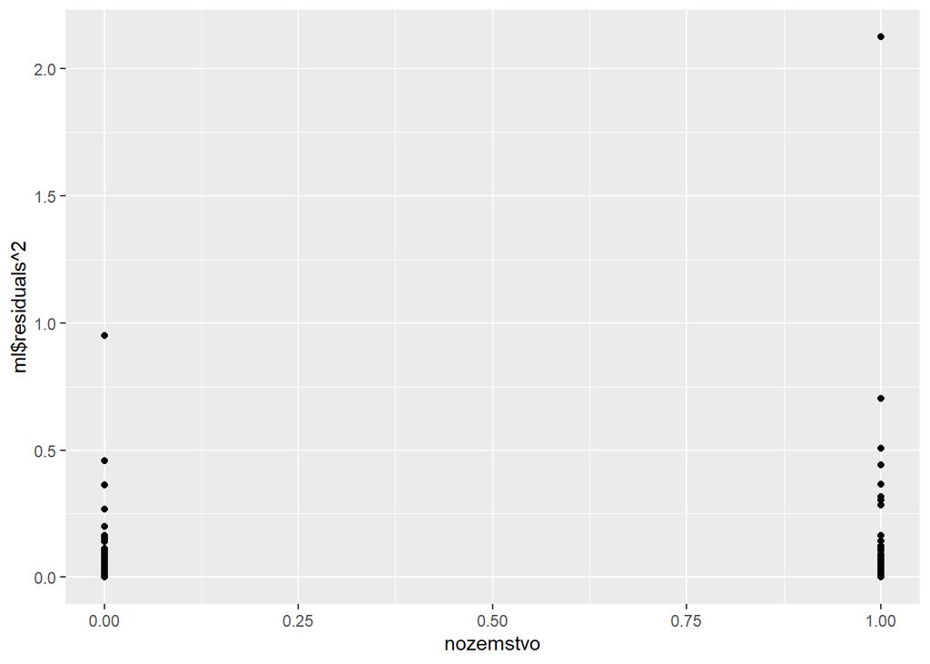

```r
ggplot(data = data, aes(nozemstvo,ml$residuals^2 )) + geom_point()
```

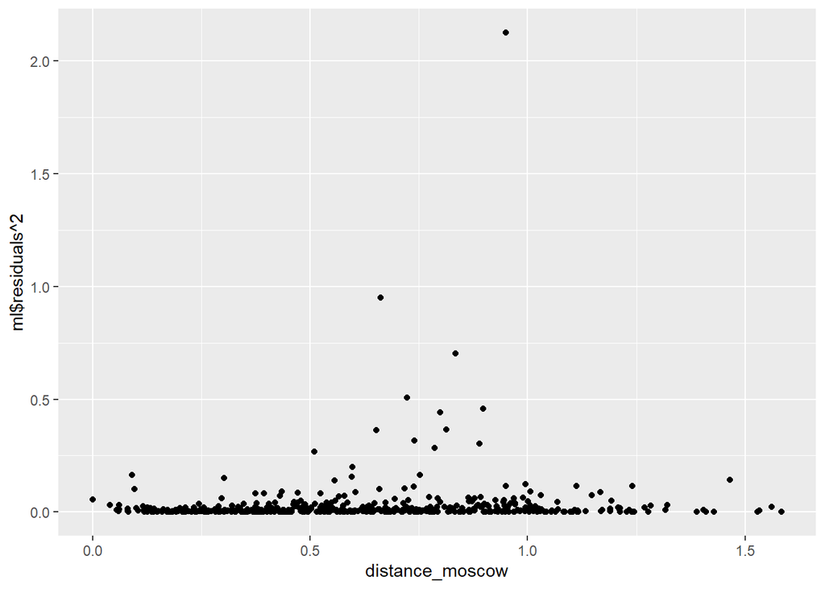

```r
ggplot(data = data, aes(distance_moscow,ml$residuals^2 )) + geom_point()
```

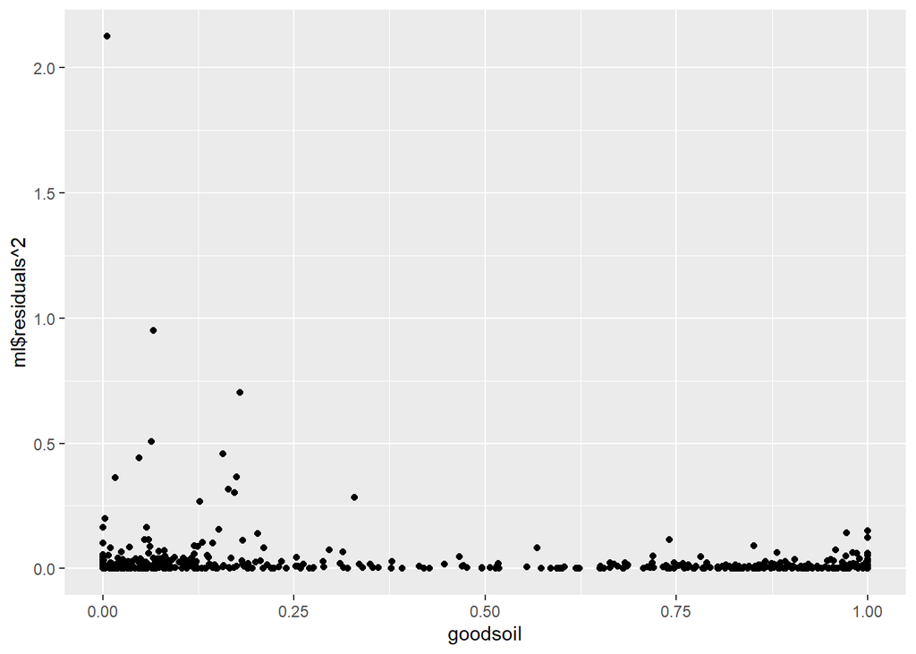

```r
ggplot(data = data, aes(goodsoil,ml$residuals^2 )) + geom_point()
```

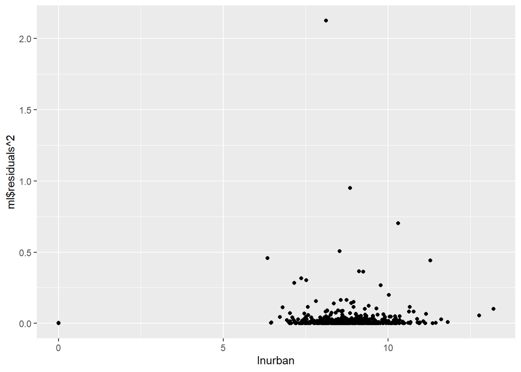

```r
ggplot(data = data, aes(lnurban,ml$residuals^2 )) + geom_point()
```

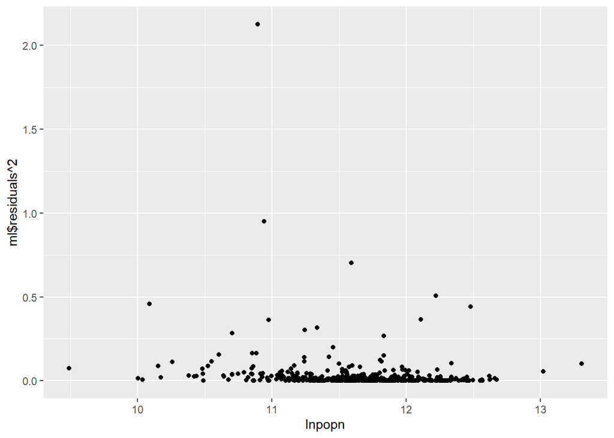

```r
ggplot(data = data, aes(lnpopn,ml$residuals^2 )) + geom_point()
```

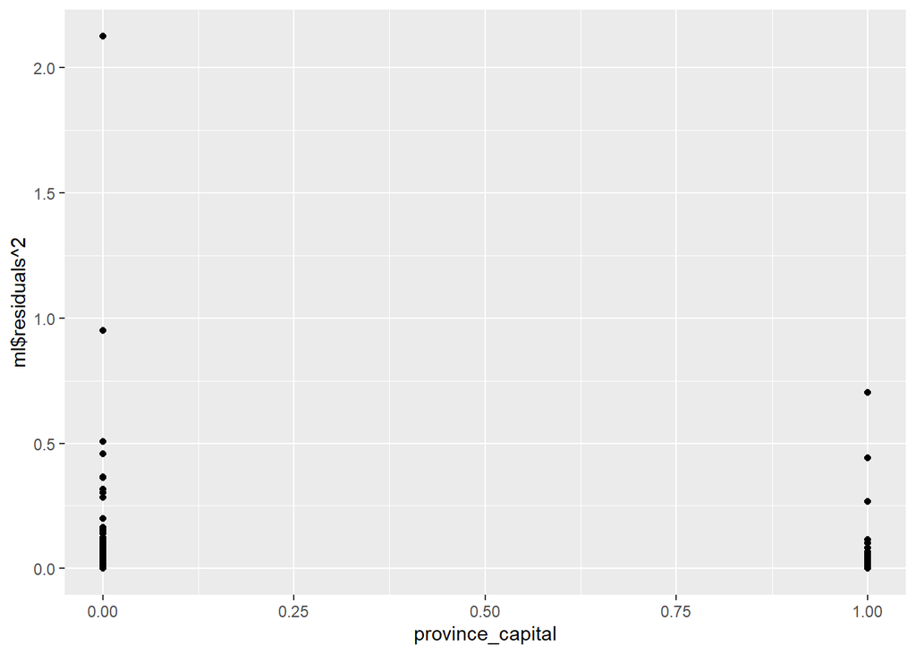

```r
ggplot(data = data, aes(province_capital,ml$residuals^2 )) + geom_point()
```

Данные графики показывают разброс ошибок относительно предикторов. Относительно одинаковый разброс можно увидеть с переменными afreq,province_capital( хотя есть выбросы) . Можем также обратить внимание на график с lnurban, distance_moscow, nozemstvo(стоит учесть, что величина бинарная ), где наблюдается относительно высокий разброс, что позволяет сделать вывод о возможном наличии гетероскедастичности.

## C fitted values

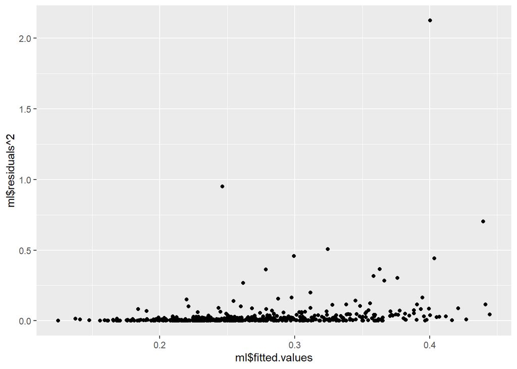

```r
ggplot(data, aes(ml$fitted.values, ml$residuals^2)) + geom_point()
```

Также можно посмотреть на разброс RSS относительно модельных значений зависимой переменной. Как видно, с ростом по оси x разброс растет, точки более рассеяны. Можем сделать общий вывод о том, что есть основания предполагать гетероскедастичность в модели. ## Формальные тесты

```r
bptest(ml) # тест Бреуша—Пагана
```

```
##
##  studentized Breusch-Pagan test
##
## data:  ml
## BP = 33.289, df = 7, p-value = 2.338e-05
```

Низкое значение p-value позволяет отвергнуть нулевую гипотезу о гомоскедастичности ( то есть отвергаем в пользу альтернативной о гетероскедастичности) Проверим зависит ли гетероскедастичность монотонно от одной из переменных.

## Goldfeld-Quandt для каждой переменной

Выведем p-values Goldfeld-Quandt теста для каждой переменной

```r
for ( i in 1:7){
  test <- gqtest(ml, order.by = ~unlist(data[,i]), data = data, fraction = 0.2)
  print(colnames(data[,i]))
  print(test$statistic)
  print(paste('P-value = ',toString(test$p.value)))
}
```

```
## [1] "afreq"
##        GQ
## 0.3729905
## [1] "P-value =  0.999999999981606"
## [1] "nozemstvo"
##       GQ
## 3.089569
## [1] "P-value =  2.77264733558766e-14"
## [1] "distance_moscow"
##       GQ
## 3.917538
## [1] "P-value =  1.10170788979054e-19"
## [1] "goodsoil"
##        GQ
## 0.2360792
## [1] "P-value =  1"
## [1] "lnurban"
##        GQ
## 0.7849639
## [1] "P-value =  0.950910424254543"
## [1] "lnpopn"
##        GQ
## 0.4070626
## [1] "P-value =  0.999999999271085"
## [1] "province_capital"
##       GQ
## 0.773797
## [1] "P-value =  0.960057734965548"
```

Можно заметить, что у переменных distance_moscow и nozemstvo высокий показатель статистики теста(GQ) и низкий p-value ( то есть отвергается нулевая гипотезу в пользу гипотезы о гетероскедастичности). Можем полагать, что из-за данных предикторов возникла гетероскедастичность в модели.Так как мы обнаружили гетероскедастичность, переоценим стандартные ошибки.

## Посмотрим на стандартные ошибки

```r
print('Результаты начальной модели')
```

```
## [1] "Результаты начальной модели"
```

```r
coeftest(ml)
```

```
##
## t test of coefficients:
##
##                         Estimate Std. Error t value  Pr(>|t|)
## (Intercept)            0.6763896  0.2182529  3.0991 0.0020550 **
## data$afreq            -0.1799397  0.0543913 -3.3082 0.0010094 **
## data$nozemstvo         0.0816815  0.0218245  3.7427 0.0002041 ***
## data$distance_moscow  -0.0122836  0.0318804 -0.3853 0.7001841
## data$goodsoil         -0.0094062  0.0240049 -0.3918 0.6953471
## data$lnurban           0.0137544  0.0072813  1.8890 0.0594936 .
## data$lnpopn           -0.0420321  0.0198827 -2.1140 0.0350298 *
## data$province_capital  0.0387709  0.0301889  1.2843 0.1996642
## ---
## Signif. codes:  0 '***' 0.001 '**' 0.01 '*' 0.05 '.' 0.1 ' ' 1
```

```r
print('Переоцененные ошибки')
```

```
## [1] "Переоцененные ошибки"
```

```r
coeftest(ml, vcov=vcovHC(ml))
```

```
##
## t test of coefficients:
##
##                         Estimate Std. Error t value Pr(>|t|)
## (Intercept)            0.6763896  0.3203236  2.1116  0.03524 *
## data$afreq            -0.1799397  0.0620089 -2.9018  0.00388 **
## data$nozemstvo         0.0816815  0.0278594  2.9319  0.00353 **
## data$distance_moscow  -0.0122836  0.0313559 -0.3917  0.69542
## data$goodsoil         -0.0094062  0.0214840 -0.4378  0.66171
## data$lnurban           0.0137544  0.0048067  2.8615  0.00440 **
## data$lnpopn           -0.0420321  0.0285810 -1.4706  0.14205
## data$province_capital  0.0387709  0.0332708  1.1653  0.24447
## ---
## Signif. codes:  0 '***' 0.001 '**' 0.01 '*' 0.05 '.' 0.1 ' ' 1
```

### Задание 3. Нетипичные наблюдения

## График взаимосвязи hat-values и Стьюдентизированных остатков

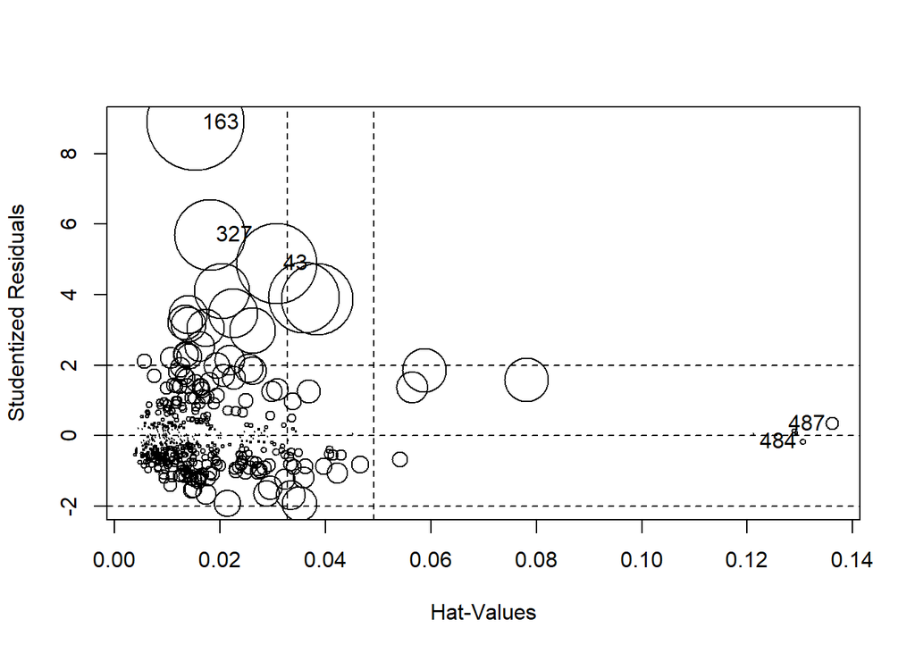

```
##        StudRes        Hat        CookD
## 43   4.8950648 0.03072335 0.0906053850
## 163  8.8920153 0.01532433 0.1322979180
## 327  5.7002188 0.01798865 0.0698195447
## 484 -0.1621718 0.13060397 0.0004948588
## 487  0.3502760 0.13608087 0.0024201882
```

```r
car::influencePlot(ml) # hat-values VS Studentized residuals (visualize Cook's measure)
```

На данном графике мы можем увидеть собственно выбросы ( в левой части): 163,327,43. Также можно увидеть leverage (наблюдения с большим потенциалом влияния ) - 487,484. Нетипичные наблюдения могут влиять на моделирование напрямую - могут “перетягивать” на себя взаимосвязь ( в случае leverage по предиктору) или даже сдвигать прямую регрессию ( выбросы), более того может меняться характер взаимосвязи( допустим с положительного на отрицательный и наоборот). Посмотрим как изменится модель, если переоценить ее без некоторых влиятельных наблюдений.

## Переоцениваем модель без трех наиболее влиятельных наблюдений

```r
influence_data <- augment(ml) %>% mutate(index = 1:n()) #с influence и id
```

Посмотрим какие три наблюдения наиболее влиятельные по мере Кука.

```r
top_cook <- influence_data %>% top_n(3, .cooksd)
top_cook[,-1:-8]
```

```
## # A tibble: 3 x 8
##   .fitted .se.fit .resid   .hat .sigma .cooksd .std.resid index
##     <dbl>   <dbl>  <dbl>  <dbl>  <dbl>   <dbl>      <dbl> <int>
## 1   0.439  0.0312  0.839 0.0307  0.174  0.0906       4.78    43
## 2   0.403  0.0349  0.664 0.0384  0.176  0.0723       3.80   160
## 3   0.400  0.0221  1.46  0.0153  0.165  0.132        8.25   163
```

Это наблюдения №43, 160 и 163.

```r
ml_updated <- update(ml, subset = c(-top_cook$index))
mtable(ml, ml_updated)
```

```
##
## Calls:
## ml: lm(formula = data$ch_schools_pc ~ data$afreq + data$nozemstvo +
##     data$distance_moscow + data$goodsoil + data$lnurban + data$lnpopn +
##     data$province_capital, data = data)
## ml_updated: lm(formula = data$ch_schools_pc ~ data$afreq + data$nozemstvo +
##     data$distance_moscow + data$goodsoil + data$lnurban + data$lnpopn +
##     data$province_capital, data = data, subset = c(-top_cook$index))
##
## =================================================
##                              ml      ml_updated
## -------------------------------------------------
##   (Intercept)              0.676**     0.677***
##                           (0.218)     (0.194)
##   data$afreq              -0.180**    -0.125*
##                           (0.054)     (0.048)
##   data$nozemstvo           0.082***    0.060**
##                           (0.022)     (0.019)
##   data$distance_moscow    -0.012      -0.008
##                           (0.032)     (0.028)
##   data$goodsoil           -0.009      -0.001
##                           (0.024)     (0.021)
##   data$lnurban             0.014       0.013*
##                           (0.007)     (0.006)
##   data$lnpopn             -0.042*     -0.043*
##                           (0.020)     (0.018)
##   data$province_capital    0.039       0.013
##                           (0.030)     (0.027)
## -------------------------------------------------
##   R-squared                0.103       0.076
##   N                      488         485
## =================================================
##   Significance: *** = p < 0.001;
##                 ** = p < 0.01; * = p < 0.05
```

Как можно увидеть из сравнительной таблицы значимыми остались в общем-то те же предикторы, хотя lnurban тоже обозначился как значимый. Предикторы afreq, nozemstvo также менее значимыми, в то время как intercept стал более. Стоит также обратить внимание на стандартные ошибки: во всех случаях они стали меньше. Значимо результаты, в целом, не изменились( оценки поменялись малозначительно, значимость сохранилась на тех же предикторах).Также мы видим, что характер связи между предикторами и зависимой переменной не изменился ( остался отрицательным там, где и был). Также можно посмотреть на коэффициент детерминации он стал немного ниже( около 8% вместо 10%). С одной стороны можно сказать, что коэффициент детерминации значимо не поменялся, с другой стороны разница в 2% из-за всего лишь 3-х наблюдений может говорить, что небольшое влияние выбросы имели. В целом обе модели показали одинаковые результаты.